# MDS plot and Venn diagram of wild sea otter-associated sample types

Natasha Dudek

03/12/2018

Set paths + working directory and load phyloseq object (wild sea otter dataset)

```r
#path <- file.path("/Users", "path", "to", "dir", fsep="/") # path to working dir
path <- file.path("/Users", "natasha", "Desktop", "sea_otters", fsep="/")
setwd(path)
getwd()
```

```
## [1] "/Users/natasha/Desktop/sea_otters"
```

```r
physeq <- readRDS("physeq_lane1.rds")
```

Load libraries

```r
library("ggplot2"); packageVersion("ggplot2")
```

```
## [1] '3.3.2'
```

```r
library("nVennR"); packageVersion("nVennR")
```

```
## [1] '0.2.2'
```

```r
library("phyloseq"); packageVersion("phyloseq")
```

```
## [1] '1.28.0'
```

```r
library("plyr"); packageVersion("plyr")
```

```
## [1] '1.8.6'
```

ggplot2 package theme set

```r
theme_set(theme_bw())
```

Filter out non-relevant samples  
- Select only wild sea otters (facility = CDFW)  
- Select only one sample per individual sea otter and sample type  
- Select only gingival, rectal, and seawater samples

```r
physeq <- subset_samples(physeq, facility == "CDFW")
physeq <- subset_samples(physeq, duplicate_capture == "no")
physeq <- subset_samples(physeq, sample_type != "fecal")
```

How many of each sample type do we have?

```r
table(sample_data(physeq)$sample_type)
```

```
##
##   oral rectal  water
##    145    121     79
```

## Ordinate

Remove ASVs that do not appear more than 5 times in at least 1% of samples. This helps protect against ASVs with small mean & trivially large C.V.

```r
temp = genefilter_sample(physeq, filterfun_sample(function(x) x > 5), A=0.01*nsamples(physeq))
physeq_filtered = prune_taxa(temp, physeq)
```

Perform MDS ordination using four diversity metrics  
These metrics were selected such that all combinations of the following characteristics are accounted for:  
a) Presence/absence only, b) relative abundance  
a) Phylogenetically uniformed, b) phylogenetically informed

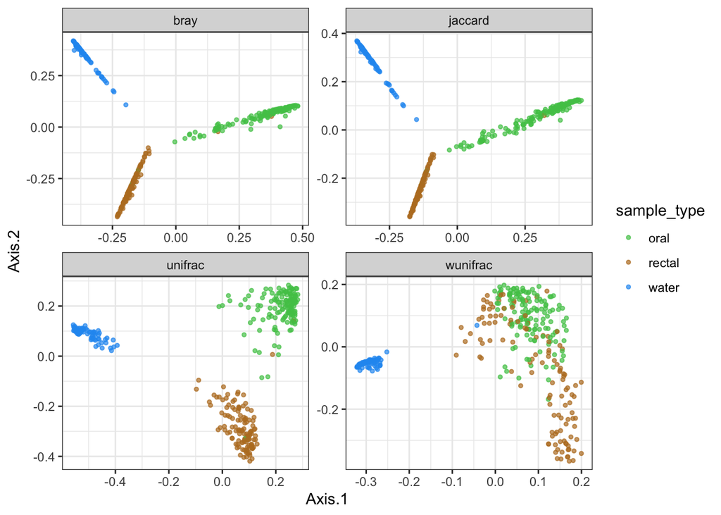

```r
dist_methods = c("jaccard","unifrac","bray","wunifrac")

plist <- vector("list", length(dist_methods))
names(plist) = dist_methods


for( i in dist_methods ){
    iDist <- distance(physeq_filtered, method=i)
    iMDS  <- ordinate(physeq_filtered, "MDS", distance=iDist)
    evals <- iMDS$values$Eigenvalues
    p <- NULL
    p <- plot_ordination(physeq_filtered, iMDS, color="sample_type") +
  coord_fixed(sqrt(evals[2] / evals[1]))
    plist[[i]] = p
}

df = ldply(plist, function(x) x$data)
names(df)[1] <- "distance"
p = ggplot(df, aes(Axis.1, Axis.2, color=sample_type))
p = p + geom_point(size=1, alpha=0.7)
p = p + facet_wrap(~distance, scales="free")
p = p + scale_color_manual(values = c("#4fc657", "#ba7d28", "#269af2"))
p
```

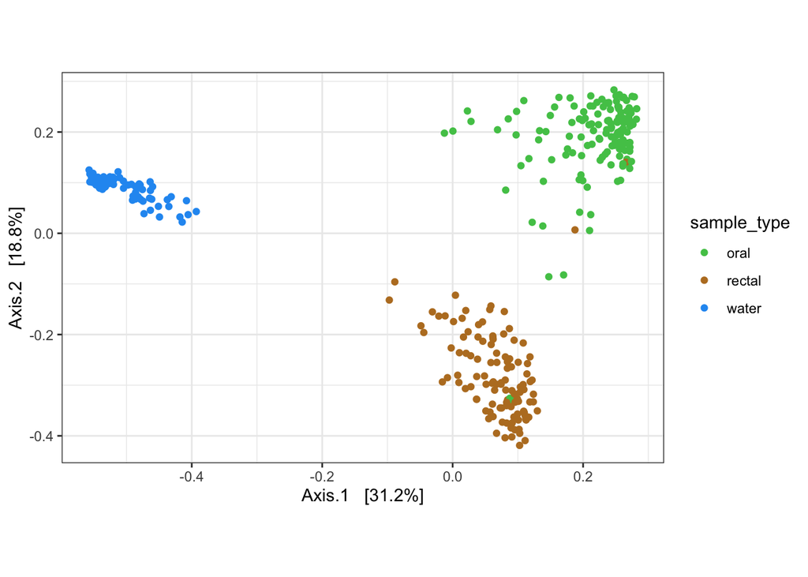

```r
physeq_filtered.ord <- ordinate(physeq_filtered, "MDS", "unifrac")

evals <- physeq_filtered.ord$values$Eigenvalues

p2 = plot_ordination(physeq_filtered, physeq_filtered.ord, color="sample_type") +
  coord_fixed(sqrt(evals[2] / evals[1]))

p2 = p2 + scale_color_manual(values = c("#4fc657", "#ba7d28", "#269af2"))
ggsave('Fig2C.pdf', plot = p2)
p2
```

## Plot the Venn diagram showing sets of ASVs in gingival, rectal, and seawater samples

Use phyloseq object before filtering to remove ASVs that do not appear more than 5 times in at least 1% of samples. Instead we will just remove ASVs with zero reads.

```r
physeq = filter_taxa(physeq, function(x) sum(x) > 0, TRUE)
```

Select only sea otters for whom there is a gingival, rectal, and adjacent seawater sample  
i.e. whose BRD number shows up three times (remember there is a max of only one of each sample type per sea otter)

```r
brd_list <- sample_data(physeq)$brd_number
count_brds <- table(brd_list)
keeper_brds <- names(count_brds)[count_brds == 3]
venn_physeq <- subset_samples(physeq, brd_number %in% keeper_brds)
```

How many sea otters have samples meeting these criteria?

```r
length(names(count_brds)[count_brds == 3])
```

```
## [1] 60
```

Select only sea otters for which all three samples were collected on the same day

```r
day <- sample_data(venn_physeq)$day_captured
month <- sample_data(venn_physeq)$month_captured
year <- sample_data(venn_physeq)$year_captured

u_keeper_brds <- unique(keeper_brds)
strict_keepers <- c()
for (i in u_keeper_brds){
    temp_physeq <- subset_samples(venn_physeq, brd_number == i)

    day <- sample_data(temp_physeq)$day_captured
    month <- sample_data(temp_physeq)$month_captured
    year <- sample_data(temp_physeq)$year_captured

    if ((!(NA %in% day)) & (!(NA %in% month)) & (!(NA %in% year)) & (length(unique(day)) == 1) & (length(unique(month)) == 1) & (length(unique(year)) == 1)){
        strict_keepers <- append(strict_keepers, i)
    }
}

venn_physeq <- subset_samples(physeq, brd_number %in% strict_keepers)
```

How many sea otters are we looking at now?

```r
length(strict_keepers)
```

```
## [1] 59
```

Rarify samples with replacement - need equal sampling depth  
Note: trimOTUs function removes all OTUs not present in the rarified dataset after subsampling

```r
min(sample_sums(venn_physeq))
```

```
## [1] 27712
```

```r
rarified_physeq <- rarefy_even_depth(venn_physeq, sample.size = min(sample_sums(venn_physeq)), rngseed = 290518, replace = TRUE, trimOTUs = TRUE, verbose = TRUE)
```

```
## `set.seed(290518)` was used to initialize repeatable random subsampling.
```

```
## Please record this for your records so others can reproduce.
```

```
## Try `set.seed(290518); .Random.seed` for the full vector
```

```
## ...
```

```
## 6422OTUs were removed because they are no longer
## present in any sample after random subsampling
```

```
## ...
```

Sampling depth

```r
unique(sample_sums(rarified_physeq))
```

```
## [1] 27712
```

Number of ASVs found in all samples

```r
total_num <- ntaxa(rarified_physeq)
total_num
```

```
## [1] 13952
```

Number of ASVs found in rectal samples ONLY

```r
gingival_water <- subset_samples(rarified_physeq, sample_type == "oral" | sample_type == "water")
gingival_water = filter_taxa(gingival_water, function(x) sum(x) > 0, TRUE)
num_rectal_only <- total_num - ntaxa(gingival_water)
num_rectal_only
```

```
## [1] 1829
```

Number of ASVs found in gingival samples ONLY

```r
rectal_water <- subset_samples(rarified_physeq, sample_type == "rectal" | sample_type == "water")
rectal_water = filter_taxa(rectal_water, function(x) sum(x) > 0, TRUE)
num_gingival_only <- total_num - ntaxa(rectal_water)
num_gingival_only
```

```
## [1] 777
```

Number of ASVs found in water samples ONLY

```r
gingival_rectal <- subset_samples(rarified_physeq, sample_type == "rectal" | sample_type == "oral")
gingival_rectal = filter_taxa(gingival_rectal, function(x) sum(x) > 0, TRUE)
num_water_only <- total_num - ntaxa(gingival_rectal)
num_water_only
```

```
## [1] 10491
```

Number of ASVs shared by rectal and gingival samples only

```r
water <- subset_samples(rarified_physeq, sample_type == "water")
water = filter_taxa(water, function(x) sum(x) > 0, TRUE)
num_water <- ntaxa(water)
num_shared_gingival_rectal = total_num - num_water - num_gingival_only - num_rectal_only
num_shared_gingival_rectal
```

```
## [1] 194
```

Number of ASVs shared by gingival and water samples only

```r
rectal <- subset_samples(rarified_physeq, sample_type == "rectal")
rectal = filter_taxa(rectal, function(x) sum(x) > 0, TRUE)
num_rectal <- ntaxa(rectal)
num_shared_gingival_water = total_num - num_rectal - num_gingival_only - num_water_only
num_shared_gingival_water
```

```
## [1] 154
```

Number of ASVs found in rectal and water samples only

```r
gingival <- subset_samples(rarified_physeq, sample_type == "oral")
gingival = filter_taxa(gingival, function(x) sum(x) > 0, TRUE)
num_gingival <- ntaxa(gingival)
num_shared_rectal_water = total_num - num_gingival - num_water_only - num_rectal_only
num_shared_rectal_water
```

```
## [1] 331
```

Number of ASVs found in all three sample types

```r
num_shared = total_num - num_gingival_only - num_rectal_only - num_water_only - num_shared_gingival_rectal - num_shared_gingival_water - num_shared_rectal_water
num_shared
```

```
## [1] 176
```

Now make the Venn diagram – adjust labels later in Inkscape.

```r
myV3 <- createVennObj(nSets = 3, sSizes = c(rep(1, 7)))

myV3 <- setVennRegion(myV3, region = c("Group1"), value = as.numeric(num_gingival_only[1]))
myV3 <- setVennRegion(myV3, region = c("Group2"), value = as.numeric(num_rectal_only[1]))
myV3 <- setVennRegion(myV3, region = c("Group3"), value = as.numeric(num_water_only[1]))

myV3 <- setVennRegion(myV3, region = c("Group1","Group2"), value = as.numeric(num_shared_gingival_rectal[1]))
myV3 <- setVennRegion(myV3, region = c("Group1","Group3"), value = as.numeric(num_shared_gingival_water[1]))
myV3 <- setVennRegion(myV3, region = c("Group2","Group3"), value = as.numeric(num_shared_rectal_water[1]))

myV3 <- setVennRegion(myV3, region = c("Group1","Group2","Group3"), as.numeric(num_shared[1]))

myV3 <- plotVenn(nVennObj = myV3)
```

```
## The figure cannot be rendered in the plot window. Please, use the arguments outFile and/or systemShow.
```

```r
showSVG(myV3, setColors = c("#4fc657", "#ba7d28", "#269af2"), opacity = 0.1, borderWidth = 3, fontScale = 2, outFile="Fig2D.svg")
```